# Fishing Dynamics and Ecosystem Effects in ZooMSS

```r
library(zoomss)
library(ggplot2)
library(patchwork)
library(dplyr)
```

## Introduction

This vignette explores how effort-driven fishing mortality affects the ZooMSS marine ecosystem over multi-decadal timescales. We examine:

1. **Trophic cascades** — how removing fish biomass propagates through zooplankton communities
2. **Size spectra distortion** — how fishing steepens the community size spectrum
3. **Stock–recruitment dynamics** — how SSB and recruitment respond under sustained exploitation
4. **Fishing intensity gradients** — equilibrium responses across a range of effort levels
5. **Pulse fishing and recovery** — ecosystem resilience after fishing cessation

Throughout, we use the effort-driven fishing framework where fishing mortality is calculated dynamically as $F(w,t) = \text{Effort}(t) \times q \times \text{Selectivity}(w)$.

## Helper Functions

We define a few helper functions used throughout the vignette for extracting and plotting fishing-specific outputs.

```r
# Extract catch data frame from model output
extract_catch <- function(mdl, fish_names = c("Fish_Small", "Fish_Med", "Fish_Large")) {
  data.frame(
    time = rep(mdl$time, times = length(fish_names)),
    catch = as.vector(mdl$catch),
    group = rep(fish_names, each = length(mdl$time))
  )
}

# Extract total biomass per group over time
extract_biomass_ts <- function(mdl) {
  species <- mdl$param$Groups$Species
  ngrps <- mdl$param$ngrps
  nsave <- length(mdl$time)

  # Sum biomass across size classes for each group
  bm <- matrix(NA, nrow = nsave, ncol = ngrps)
  for (g in 1:ngrps) {
    bm[, g] <- rowSums(mdl$biomass[g, , drop = FALSE] *
                          matrix(mdl$param$w, nrow = 1)[rep(1, nsave), ] *
                          mdl$param$dx)
  }
  # Actually use the abundance array directly
  bm <- matrix(NA, nrow = nsave, ncol = ngrps)
  for (g in 1:ngrps) {
    bm[, g] <- apply(mdl$abundance[, g, , drop = FALSE], 1, function(row) {
      sum(row * mdl$param$w * mdl$param$dx)
    })
  }

  df <- data.frame(
    time = rep(mdl$time, times = ngrps),
    biomass = as.vector(bm),
    species = rep(species, each = nsave),
    type = rep(mdl$param$Groups$Type, each = nsave)
  )
  df$species <- factor(df$species, levels = species)
  df
}

# Get consistent fish colours
get_fish_colours <- function(mdl) {
  fc <- mdl$param$Groups$PlotColour[mdl$param$fish_grps]
  names(fc) <- mdl$param$Groups$Species[mdl$param$fish_grps]
  fc
}

# Get all group colours
get_all_colours <- function(mdl) {
  ac <- mdl$param$Groups$PlotColour
  names(ac) <- mdl$param$Groups$Species
  ac
}
```

## Part 1: Unfished Baseline

First, we establish an unfished equilibrium as a reference. We run for 200 years with constant environment to reach steady state.

```r
Groups <- getGroups()

env_base <- createInputParams(
  time = seq(0, 200, by = 0.1),
  sst = 15,
  chl = 1.0
)
```

```
#> ZooMSS input parameters created:
#> - Time points: 2001 (time values provided)
#> - Time steps: 2000 (intervals to simulate)
#> - Time range: 0 to 200 years
#> - dt = 0.1 years
#> - SST range: 15 to 15 deg C
#> - Chlorophyll range: 1 to 1 mg/m^3
```

```r
mdl_unfished <- zoomss_model(input_params = env_base, Groups = Groups, isave = 5)
```

```
#> Calculating phytoplankton parameters from environmental time series
#> Energy budget loaded for 12 groups (Scenario A )
#>   f_M range:       0.3 0.55
#>   K_growth range:   0.25 0.55
#>   R_frac range:     0 0.2
```

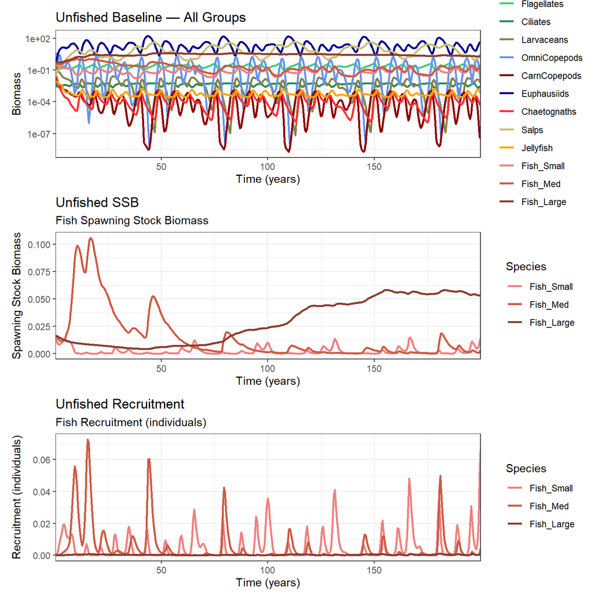

```r
p1 <- plotTimeSeries(mdl_unfished, by = "biomass", transform = "log10") +
  ggtitle("Unfished Baseline — All Groups")

p2 <- plotReproduction(mdl_unfished, by = "SSB") +
  ggtitle("Unfished SSB")

p3 <- plotReproduction(mdl_unfished, by = "recruitment") +
  ggtitle("Unfished Recruitment")

wrap_plots(p1, p2, p3, ncol = 1)
```

## Part 2: Constant Fishing — Trophic Cascades

We now apply constant fishing across all three fish groups and observe how the ecosystem responds. We use moderate catchability values and compare against the unfished baseline.

```r
Groups_fished <- setFishingParams(Groups,
                                  q_small = 0.01,
                                  q_med   = 0.02,
                                  q_large = 0.03)
```

```
#> Fishing parameters set:
#>    Fish_Small : q = 0.01 , selectivity range [ 0 , 2 ] log10 g
#>    Fish_Med : q = 0.02 , selectivity range [ 2 , 4 ] log10 g
#>    Fish_Large : q = 0.03 , selectivity range [ 4 , 6 ] log10 g
```

```r
env_fished <- createInputParams(
  time = seq(0, 200, by = 0.1),
  sst = 15,
  chl = 1.0
)
```

```
#> ZooMSS input parameters created:
#> - Time points: 2001 (time values provided)
#> - Time steps: 2000 (intervals to simulate)
#> - Time range: 0 to 200 years
#> - dt = 0.1 years
#> - SST range: 15 to 15 deg C
#> - Chlorophyll range: 1 to 1 mg/m^3
```

```r
env_fished <- addFishingEffort(env_fished,
                               effort_small = 1.0,
                               effort_med   = 1.0,
                               effort_large = 1.0)
```

```
#> Fishing effort added to input_params:
#>   effort_small: range [ 1 1 ]
#>   effort_med:   range [ 1 1 ]
#>   effort_large: range [ 1 1 ]
```

```r
mdl_fished <- zoomss_model(input_params = env_fished, Groups = Groups_fished, isave = 5)
```

```
#> Calculating phytoplankton parameters from environmental time series
#> Energy budget loaded for 12 groups (Scenario A )
#>   f_M range:       0.3 0.55
#>   K_growth range:   0.25 0.55
#>   R_frac range:     0 0.2
#> Effort time series detected — enabling effort-driven fishing
#>   Catchability (q): Fish_Small = 0.01, Fish_Med = 0.02, Fish_Large = 0.03
#>   Effort columns: effort_small, effort_med, effort_large
```

### Fish Biomass: Fished vs Unfished

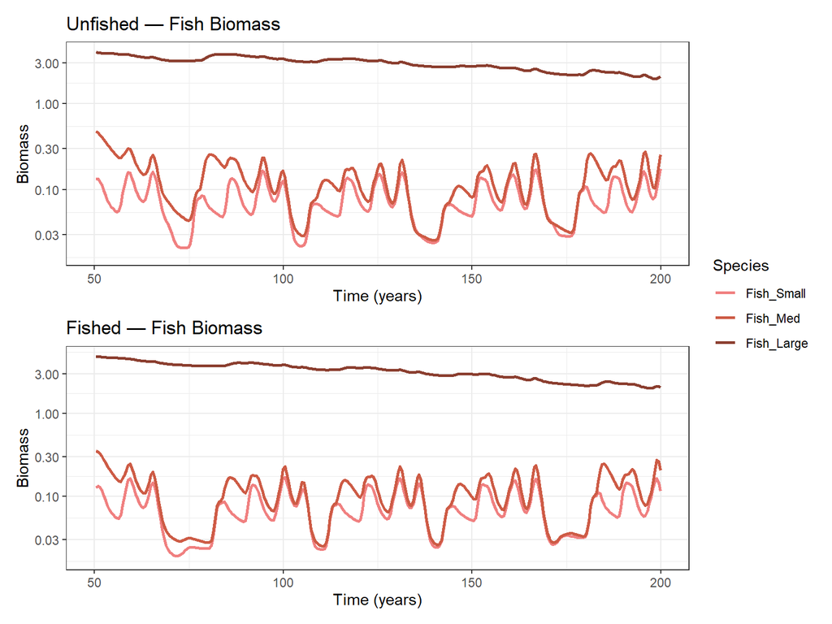

```r
fish_names <- c("Fish_Small", "Fish_Med", "Fish_Large")

p_unfished <- plotTimeSeries(mdl_unfished, by = "biomass",
                             species = fish_names, transform = "log10") +
  ggtitle("Unfished — Fish Biomass") +
  xlim(50, 200)

p_fished <- plotTimeSeries(mdl_fished, by = "biomass",
                           species = fish_names, transform = "log10") +
  ggtitle("Fished — Fish Biomass") +
  xlim(50, 200)

wrap_plots(p_unfished, p_fished, ncol = 1, guides = "collect")
```

### Catch Time Series

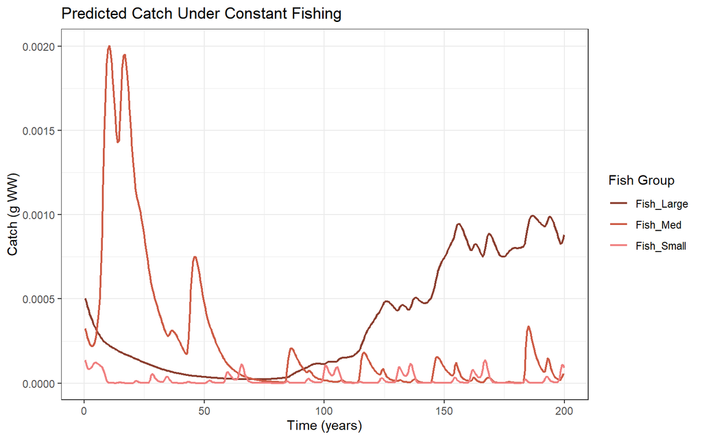

```r
fish_colours <- get_fish_colours(mdl_fished)

catch_df <- extract_catch(mdl_fished)

ggplot(catch_df, aes(x = time, y = catch, colour = group)) +
  geom_line(linewidth = 0.8) +
  scale_colour_manual(values = fish_colours) +
  theme_bw() +
  labs(x = "Time (years)", y = "Catch (g WW)",
       colour = "Fish Group", title = "Predicted Catch Under Constant Fishing")
```

### Community Composition: Trophic Cascade Effects

Removing fish biomass through fishing releases predation pressure on zooplankton, potentially allowing zooplankton biomass to increase — a trophic cascade. We compare community composition between fished and unfished scenarios.

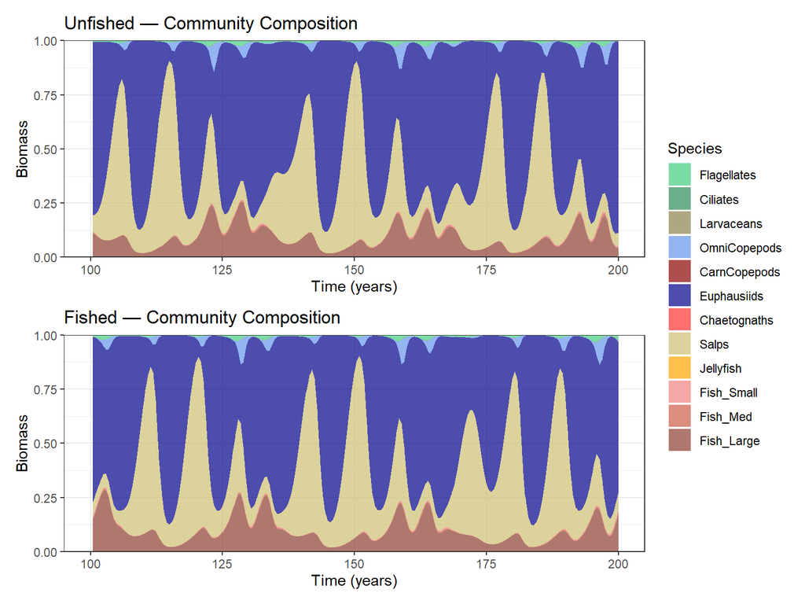

```r
p_unfished_fill <- plotTimeSeries(mdl_unfished, by = "biomass", type = "fill") +
  ggtitle("Unfished — Community Composition") +
  xlim(100, 200)

p_fished_fill <- plotTimeSeries(mdl_fished, by = "biomass", type = "fill") +
  ggtitle("Fished — Community Composition") +
  xlim(100, 200)

wrap_plots(p_unfished_fill, p_fished_fill, ncol = 1, guides = "collect")
```

### Size Spectra Distortion

Fishing selectively removes larger individuals, steepening the community size spectrum relative to the unfished state.

```r
p_spec_unfished <- plotSizeSpectra(mdl_unfished, n_years = 10) +
  ggtitle("Unfished — Size Spectrum")
```

```
#> Averaging final 10 years (20 saved time steps with isave = 5) of abundance from 400 total saved time steps.
```

```r
p_spec_fished <- plotSizeSpectra(mdl_fished, n_years = 10) +
  ggtitle("Fished — Size Spectrum")
```

```
#> Averaging final 10 years (20 saved time steps with isave = 5) of abundance from 400 total saved time steps.
```

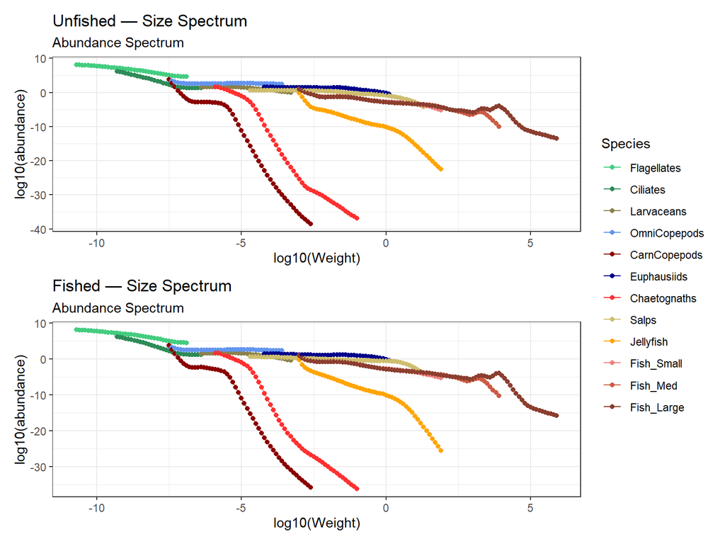

```r
wrap_plots(p_spec_unfished, p_spec_fished, ncol = 1, guides = "collect")
```

## Part 3: Stock–Recruitment Dynamics Under Fishing

Fishing reduces adult biomass, which reduces SSB, which reduces reproductive output and recruitment. This creates a feedback loop that determines the equilibrium population size under exploitation.

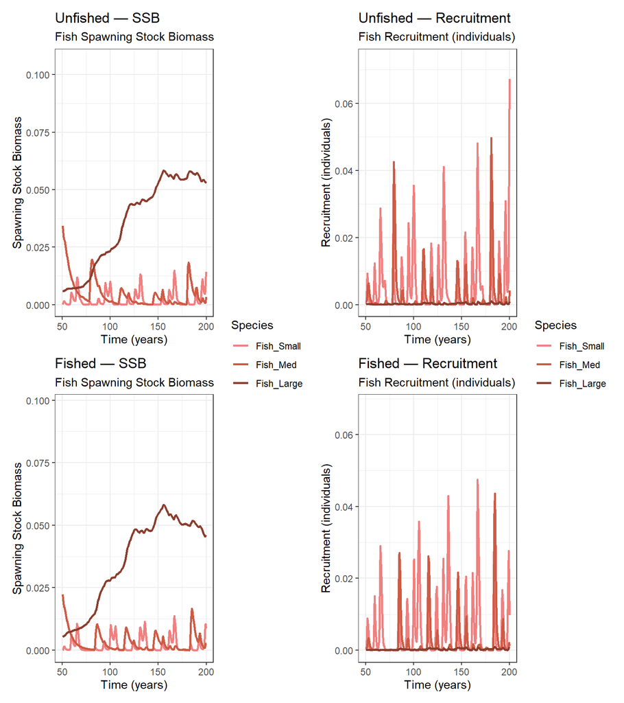

```r
p_ssb_comp <- wrap_plots(
  plotReproduction(mdl_unfished, by = "SSB") +
    ggtitle("Unfished — SSB") + xlim(50, 200),
  plotReproduction(mdl_fished, by = "SSB") +
    ggtitle("Fished — SSB") + xlim(50, 200),
  ncol = 1, guides = "collect"
)

p_rec_comp <- wrap_plots(
  plotReproduction(mdl_unfished, by = "recruitment") +
    ggtitle("Unfished — Recruitment") + xlim(50, 200),
  plotReproduction(mdl_fished, by = "recruitment") +
    ggtitle("Fished — Recruitment") + xlim(50, 200),
  ncol = 1, guides = "collect"
)

wrap_plots(p_ssb_comp, p_rec_comp, ncol = 2)
```

### Reproductive Investment by Size Under Fishing

Fishing removes the larger, more fecund individuals, shifting where reproductive investment peaks in the size spectrum.

```r
p_repro_unfished <- plotReproSizeSpectra(mdl_unfished, n_years = 10) +
  ggtitle("Unfished — Reproductive Rate by Size")
```

```
#> Averaging final 10 years (20 saved time steps with isave = 5) of repro_rate from 400 total saved time steps.
```

```r
p_repro_fished <- plotReproSizeSpectra(mdl_fished, n_years = 10) +
  ggtitle("Fished — Reproductive Rate by Size")
```

```
#> Averaging final 10 years (20 saved time steps with isave = 5) of repro_rate from 400 total saved time steps.
```

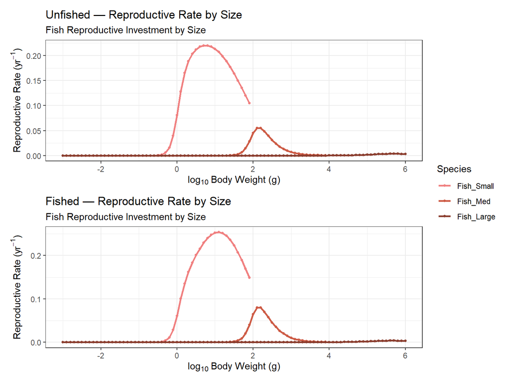

```r
wrap_plots(p_repro_unfished, p_repro_fished, ncol = 1, guides = "collect")
```

## Part 4: Fishing Intensity Gradient

To understand how the ecosystem responds across a range of fishing pressures, we run a series of simulations with increasing effort multipliers. This reveals the shape of the yield–effort curve and identifies when stock collapse becomes likely.

```r
effort_levels <- c(0, 0.25, 0.5, 1.0, 1.5, 2.0, 3.0, 5.0)

Groups_grad <- setFishingParams(Groups,
                                q_small = 1,
                                q_med   = 1,
                                q_large = 1)
```

```
#> Fishing parameters set:
#>    Fish_Small : q = 1 , selectivity range [ 0 , 2 ] log10 g
#>    Fish_Med : q = 1 , selectivity range [ 2 , 4 ] log10 g
#>    Fish_Large : q = 1 , selectivity range [ 4 , 6 ] log10 g
```

```r
results_effort <- list()

for (i in seq_along(effort_levels)) {
  env_eff <- createInputParams(
    time = seq(0, 200, by = 0.1),
    sst = 15,
    chl = 1.0
  )

  env_eff <- addFishingEffort(env_eff,
                              effort_small = effort_levels[i],
                              effort_med   = effort_levels[i],
                              effort_large = effort_levels[i])

  results_effort[[i]] <- zoomss_model(
    input_params = env_eff,
    Groups = Groups_grad,
    isave = 5
  )
}
```

```
#> ZooMSS input parameters created:
#> - Time points: 2001 (time values provided)
#> - Time steps: 2000 (intervals to simulate)
#> - Time range: 0 to 200 years
#> - dt = 0.1 years
#> - SST range: 15 to 15 deg C
#> - Chlorophyll range: 1 to 1 mg/m^3
#> Fishing effort added to input_params:
#>   effort_small: range [ 0 0 ]
#>   effort_med:   range [ 0 0 ]
#>   effort_large: range [ 0 0 ]
#> Calculating phytoplankton parameters from environmental time series
#> Energy budget loaded for 12 groups (Scenario A )
#>   f_M range:       0.3 0.55
#>   K_growth range:   0.25 0.55
#>   R_frac range:     0 0.2
#> Effort time series detected — enabling effort-driven fishing
#>   Catchability (q): Fish_Small = 1, Fish_Med = 1, Fish_Large = 1
#>   Effort columns: effort_small, effort_med, effort_large
#> ZooMSS input parameters created:
#> - Time points: 2001 (time values provided)
#> - Time steps: 2000 (intervals to simulate)
#> - Time range: 0 to 200 years
#> - dt = 0.1 years
#> - SST range: 15 to 15 deg C
#> - Chlorophyll range: 1 to 1 mg/m^3
#> Fishing effort added to input_params:
#>   effort_small: range [ 0.25 0.25 ]
#>   effort_med:   range [ 0.25 0.25 ]
#>   effort_large: range [ 0.25 0.25 ]
#> Calculating phytoplankton parameters from environmental time series
#> Energy budget loaded for 12 groups (Scenario A )
#>   f_M range:       0.3 0.55
#>   K_growth range:   0.25 0.55
#>   R_frac range:     0 0.2
#> Effort time series detected — enabling effort-driven fishing
#>   Catchability (q): Fish_Small = 1, Fish_Med = 1, Fish_Large = 1
#>   Effort columns: effort_small, effort_med, effort_large
#> ZooMSS input parameters created:
#> - Time points: 2001 (time values provided)
```

[output cut: 97 more lines]

```
#> - dt = 0.1 years
#> - SST range: 15 to 15 deg C
#> - Chlorophyll range: 1 to 1 mg/m^3
#> Fishing effort added to input_params:
#>   effort_small: range [ 5 5 ]
#>   effort_med:   range [ 5 5 ]
#>   effort_large: range [ 5 5 ]
#> Calculating phytoplankton parameters from environmental time series
#> Energy budget loaded for 12 groups (Scenario A )
#>   f_M range:       0.3 0.55
#>   K_growth range:   0.25 0.55
#>   R_frac range:     0 0.2
#> Effort time series detected — enabling effort-driven fishing
#>   Catchability (q): Fish_Small = 1, Fish_Med = 1, Fish_Large = 1
#>   Effort columns: effort_small, effort_med, effort_large
```

### Equilibrium Yield, Biomass, SSB and Recruitment vs Effort

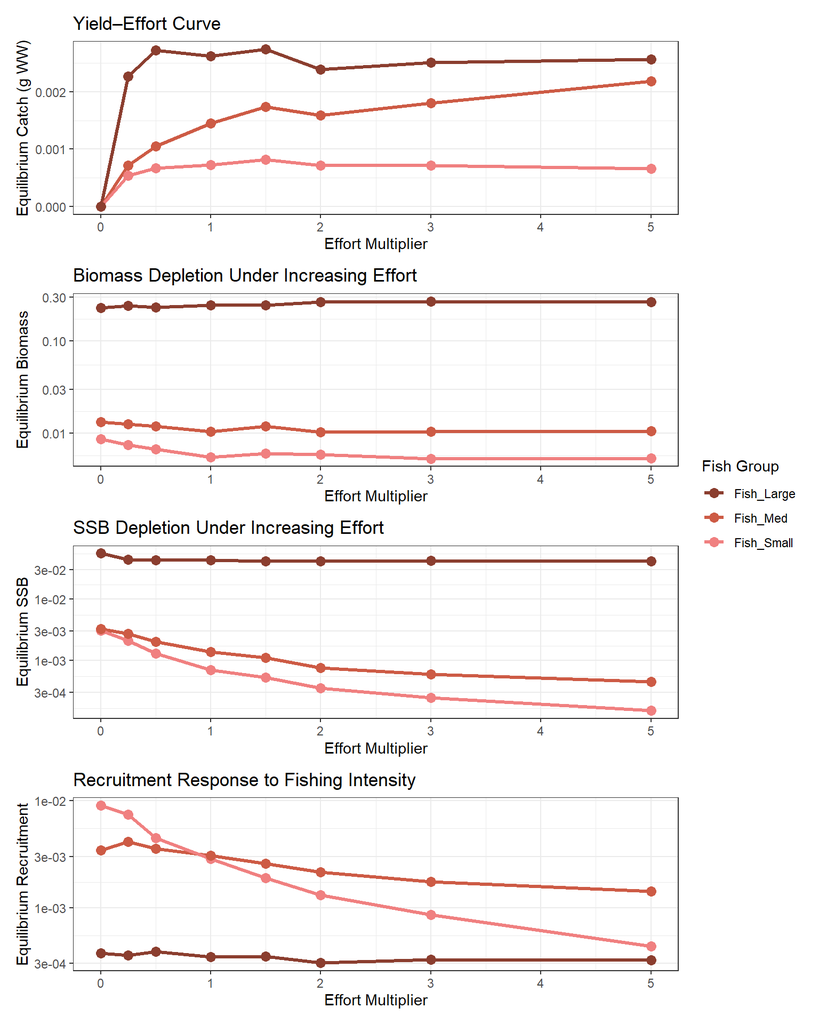

```r
num_fish <- 3
fish_names <- c("Fish_Small", "Fish_Med", "Fish_Large")

effort_summary <- data.frame(
  effort = rep(effort_levels, each = num_fish),
  fish_group = rep(fish_names, length(effort_levels)),
  eq_catch = NA,
  eq_biomass = NA,
  eq_SSB = NA,
  eq_recruitment = NA
)

for (i in seq_along(effort_levels)) {
  mdl_i <- results_effort[[i]]
  nsave <- length(mdl_i$time)
  fish_grps <- mdl_i$param$fish_grps

  # Average over final 20% of time series
  final_idx <- max(1, floor(nsave * 0.8)):nsave

  for (f in 1:num_fish) {
    row_idx <- (i - 1) * num_fish + f
    fg <- fish_grps[f]

    # Equilibrium biomass (from abundance)
    avg_biomass <- mean(apply(mdl_i$abundance[final_idx, fg, , drop = FALSE], 1, function(row) {
      sum(row * mdl_i$param$w * mdl_i$param$dx)
    }))
    effort_summary$eq_biomass[row_idx] <- avg_biomass

    # Equilibrium SSB and recruitment
    effort_summary$eq_SSB[row_idx] <- mean(mdl_i$SSB[final_idx, f], na.rm = TRUE)
    effort_summary$eq_recruitment[row_idx] <- mean(mdl_i$recruitment[final_idx, f], na.rm = TRUE)

    # Equilibrium catch
    if (!is.null(mdl_i$catch)) {
      effort_summary$eq_catch[row_idx] <- mean(mdl_i$catch[final_idx, f], na.rm = TRUE)
    } else {
      effort_summary$eq_catch[row_idx] <- 0
    }
  }
}

fish_colours <- get_fish_colours(results_effort[[1]])

# Yield–Effort curve
p_yield <- ggplot(effort_summary, aes(x = effort, y = eq_catch, colour = fish_group)) +
  geom_line(linewidth = 1.2) +
  geom_point(size = 3) +
  scale_colour_manual(values = fish_colours) +
  theme_bw() +
  labs(x = "Effort Multiplier", y = "Equilibrium Catch (g WW)",
       title = "Yield–Effort Curve", colour = "Fish Group")

# Biomass depletion
p_depletion <- ggplot(effort_summary, aes(x = effort, y = eq_biomass, colour = fish_group)) +
  geom_line(linewidth = 1.2) +
  geom_point(size = 3) +
  scale_colour_manual(values = fish_colours) +
  scale_y_log10() +
  theme_bw() +
  labs(x = "Effort Multiplier", y = "Equilibrium Biomass",
       title = "Biomass Depletion Under Increasing Effort", colour = "Fish Group")

# SSB depletion
p_ssb_depl <- ggplot(effort_summary, aes(x = effort, y = eq_SSB, colour = fish_group)) +
  geom_line(linewidth = 1.2) +
  geom_point(size = 3) +
  scale_colour_manual(values = fish_colours) +
  scale_y_log10() +
  theme_bw() +
  labs(x = "Effort Multiplier", y = "Equilibrium SSB",
       title = "SSB Depletion Under Increasing Effort", colour = "Fish Group")

# Recruitment response
p_rec_grad <- ggplot(effort_summary, aes(x = effort, y = eq_recruitment, colour = fish_group)) +
  geom_line(linewidth = 1.2) +
  geom_point(size = 3) +
  scale_colour_manual(values = fish_colours) +
  scale_y_log10() +
  theme_bw() +
  labs(x = "Effort Multiplier", y = "Equilibrium Recruitment",
       title = "Recruitment Response to Fishing Intensity", colour = "Fish Group")

wrap_plots(p_yield, p_depletion, p_ssb_depl, p_rec_grad, ncol = 1, guides = "collect")
```

The yield–effort curve is expected to show a dome shape for each fish group: at low effort, increasing fishing increases catch; beyond some optimum, overfishing reduces the stock so severely that total catch declines. The effort level at the peak approximates Maximum Sustainable Yield (MSY) for each group.

### Community Composition Across the Effort Gradient

How does the relative dominance of zooplankton vs fish change with increasing fishing pressure?

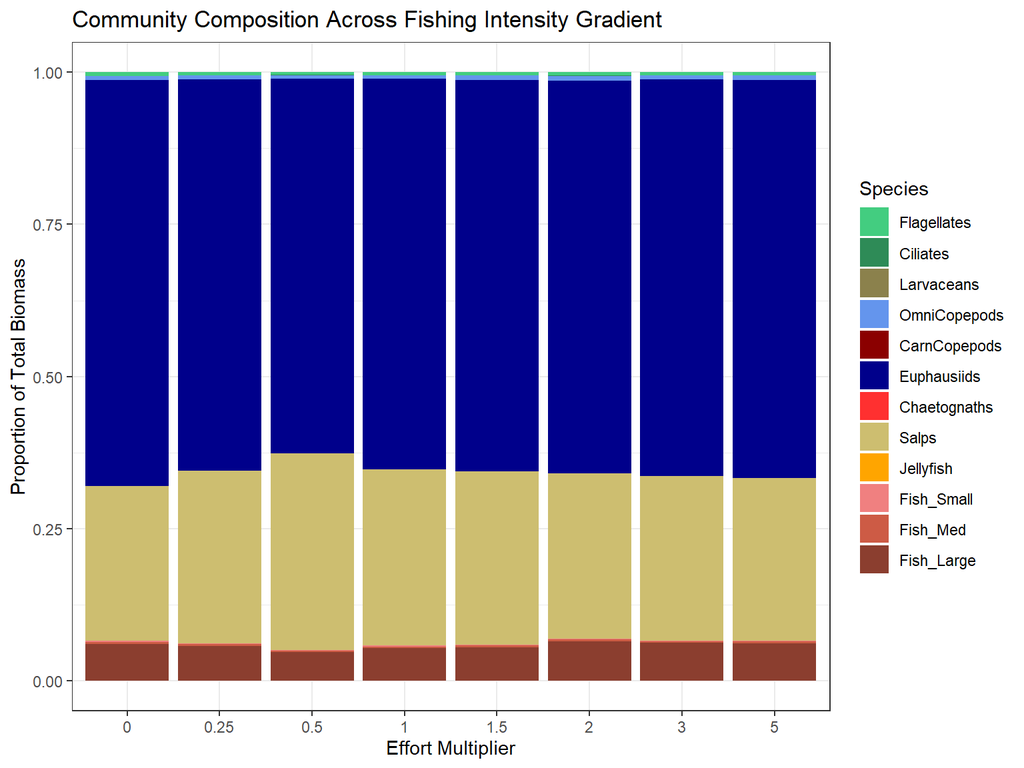

```r
# Extract equilibrium proportional composition at each effort level
comp_data <- data.frame()

for (i in seq_along(effort_levels)) {
  mdl_i <- results_effort[[i]]
  nsave <- length(mdl_i$time)
  final_idx <- max(1, floor(nsave * 0.8)):nsave
  ngrps <- mdl_i$param$ngrps
  species <- mdl_i$param$Groups$Species

  group_biomass <- numeric(ngrps)
  for (g in 1:ngrps) {
    group_biomass[g] <- mean(apply(
      mdl_i$abundance[final_idx, g, , drop = FALSE], 1, function(row) {
        sum(row * mdl_i$param$w * mdl_i$param$dx)
      }))
  }

  comp_data <- rbind(comp_data, data.frame(
    effort = effort_levels[i],
    species = species,
    biomass = group_biomass,
    type = mdl_i$param$Groups$Type
  ))
}

# Calculate proportions
comp_data <- comp_data %>%
  group_by(effort) %>%
  mutate(proportion = biomass / sum(biomass, na.rm = TRUE)) %>%
  ungroup()

comp_data$species <- factor(comp_data$species, levels = results_effort[[1]]$param$Groups$Species)

all_colours <- get_all_colours(results_effort[[1]])

ggplot(comp_data, aes(x = factor(effort), y = proportion, fill = species)) +
  geom_bar(stat = "identity", position = "stack") +
  scale_fill_manual(values = all_colours) +
  theme_bw() +
  labs(x = "Effort Multiplier", y = "Proportion of Total Biomass",
       title = "Community Composition Across Fishing Intensity Gradient",
       fill = "Species")
```

## Part 5: Selective Fishing — Targeting Large Fish Only

In practice, fishing is often size-selective. What happens if only the largest fish are targeted?

```r
Groups_large_only <- setFishingParams(Groups,
                                      q_small = 0,
                                      q_med   = 0,
                                      q_large = 0.05)
```

```
#> Fishing parameters set:
#>    Fish_Small : q = 0 , selectivity range [ 0 , 2 ] log10 g
#>    Fish_Med : q = 0 , selectivity range [ 2 , 4 ] log10 g
#>    Fish_Large : q = 0.05 , selectivity range [ 4 , 6 ] log10 g
```

```r
env_large <- createInputParams(
  time = seq(0, 200, by = 0.1),
  sst = 15,
  chl = 1.0
)
```

```
#> ZooMSS input parameters created:
#> - Time points: 2001 (time values provided)
#> - Time steps: 2000 (intervals to simulate)
#> - Time range: 0 to 200 years
#> - dt = 0.1 years
#> - SST range: 15 to 15 deg C
#> - Chlorophyll range: 1 to 1 mg/m^3
```

```r
env_large <- addFishingEffort(env_large,
                              effort_small = 1.0,
                              effort_med   = 1.0,
                              effort_large = 1.0)
```

```
#> Fishing effort added to input_params:
#>   effort_small: range [ 1 1 ]
#>   effort_med:   range [ 1 1 ]
#>   effort_large: range [ 1 1 ]
```

```r
mdl_large_only <- zoomss_model(input_params = env_large, Groups = Groups_large_only, isave = 5)
```

```
#> Calculating phytoplankton parameters from environmental time series
#> Energy budget loaded for 12 groups (Scenario A )
#>   f_M range:       0.3 0.55
#>   K_growth range:   0.25 0.55
#>   R_frac range:     0 0.2
#> Effort time series detected — enabling effort-driven fishing
#>   Catchability (q): Fish_Small = 0, Fish_Med = 0, Fish_Large = 0.05
#>   Effort columns: effort_small, effort_med, effort_large
```

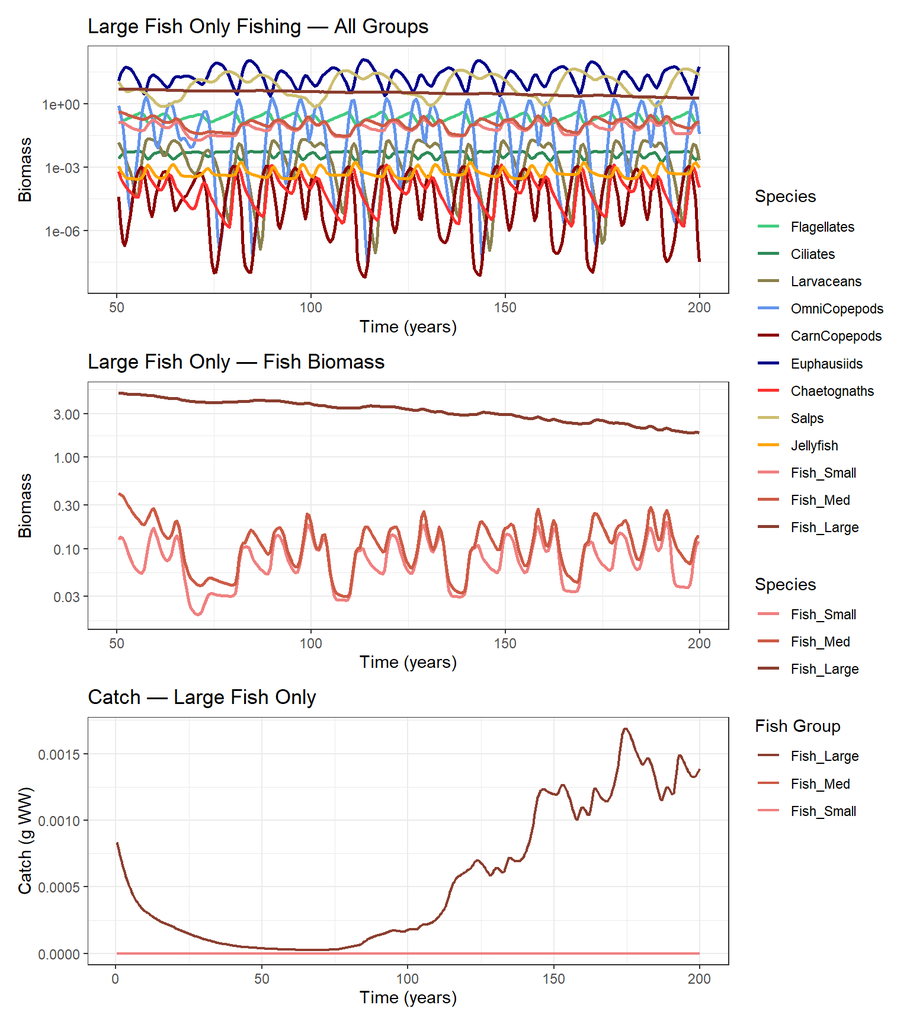

```r
p_bm_all <- plotTimeSeries(mdl_large_only, by = "biomass", transform = "log10") +
  ggtitle("Large Fish Only Fishing — All Groups") +
  xlim(50, 200)

p_bm_fish <- plotTimeSeries(mdl_large_only, by = "biomass",
                            species = fish_names, transform = "log10") +
  ggtitle("Large Fish Only — Fish Biomass") +
  xlim(50, 200)

# Catch (only large fish have non-zero catch)
catch_large <- extract_catch(mdl_large_only)
p_catch_large <- ggplot(catch_large, aes(x = time, y = catch, colour = group)) +
  geom_line(linewidth = 0.8) +
  scale_colour_manual(values = fish_colours) +
  theme_bw() +
  labs(x = "Time (years)", y = "Catch (g WW)",
       colour = "Fish Group", title = "Catch — Large Fish Only")

wrap_plots(p_bm_all, p_bm_fish, p_catch_large, ncol = 1, guides = "collect")
```

Removing only the top predator (Fish_Large) may release medium and small fish from predation, producing a mesopredator release effect that propagates down through the food web.

## Part 6: Pulse Fishing and Recovery

How quickly does the ecosystem recover after fishing stops? We simulate a fishing period followed by a recovery period to assess resilience.

```r
n_total <- 3001  # 300 years at dt = 0.1
time_vec <- seq(0, 300, by = 0.1)

# Fish for years 50-150, then stop
effort_pulse <- ifelse(time_vec >= 50 & time_vec <= 150, 1.0, 0.0)

Groups_pulse <- setFishingParams(Groups,
                                 q_small = 0.015,
                                 q_med   = 0.025,
                                 q_large = 0.04)
```

```
#> Fishing parameters set:
#>    Fish_Small : q = 0.015 , selectivity range [ 0 , 2 ] log10 g
#>    Fish_Med : q = 0.025 , selectivity range [ 2 , 4 ] log10 g
#>    Fish_Large : q = 0.04 , selectivity range [ 4 , 6 ] log10 g
```

```r
env_pulse <- createInputParams(time = time_vec, sst = 15, chl = 1.0)
```

```
#> ZooMSS input parameters created:
#> - Time points: 3001 (time values provided)
#> - Time steps: 3000 (intervals to simulate)
#> - Time range: 0 to 300 years
#> - dt = 0.1 years
#> - SST range: 15 to 15 deg C
#> - Chlorophyll range: 1 to 1 mg/m^3
```

```r
env_pulse <- addFishingEffort(env_pulse,
                              effort_small = effort_pulse,
                              effort_med   = effort_pulse,
                              effort_large = effort_pulse)
```

```
#> Fishing effort added to input_params:
#>   effort_small: range [ 0 1 ]
#>   effort_med:   range [ 0 1 ]
#>   effort_large: range [ 0 1 ]
```

```r
mdl_pulse <- zoomss_model(input_params = env_pulse, Groups = Groups_pulse, isave = 5)
```

```
#> Calculating phytoplankton parameters from environmental time series
#> Energy budget loaded for 12 groups (Scenario A )
#>   f_M range:       0.3 0.55
#>   K_growth range:   0.25 0.55
#>   R_frac range:     0 0.2
#> Effort time series detected — enabling effort-driven fishing
#>   Catchability (q): Fish_Small = 0.015, Fish_Med = 0.025, Fish_Large = 0.04
#>   Effort columns: effort_small, effort_med, effort_large
```

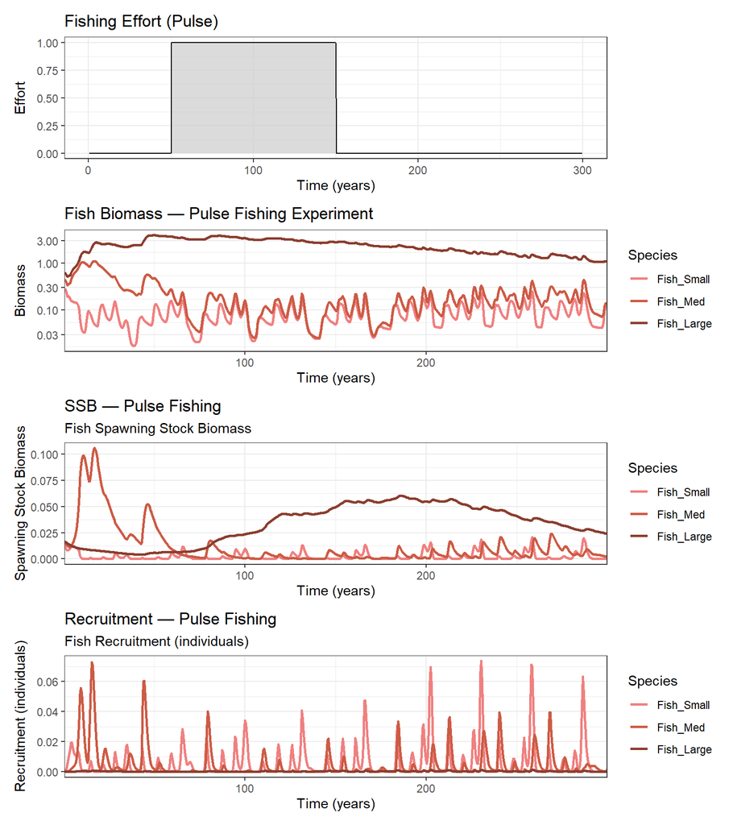

```r
# Effort time series for context
effort_df <- data.frame(time = mdl_pulse$time,
                        effort = approx(time_vec, effort_pulse, xout = mdl_pulse$time)$y)

p_effort <- ggplot(effort_df, aes(x = time, y = effort)) +
  geom_area(fill = "grey80", alpha = 0.7) +
  geom_line(linewidth = 0.5) +
  theme_bw() +
  labs(x = "Time (years)", y = "Effort", title = "Fishing Effort (Pulse)")

p_bm_pulse <- plotTimeSeries(mdl_pulse, by = "biomass",
                             species = fish_names, transform = "log10") +
  ggtitle("Fish Biomass — Pulse Fishing Experiment")

p_ssb_pulse <- plotReproduction(mdl_pulse, by = "SSB") +
  ggtitle("SSB — Pulse Fishing")

p_rec_pulse <- plotReproduction(mdl_pulse, by = "recruitment") +
  ggtitle("Recruitment — Pulse Fishing")

wrap_plots(p_effort, p_bm_pulse, p_ssb_pulse, p_rec_pulse, ncol = 1)
```

Key questions to examine: - How quickly does biomass decline once fishing starts? - Does recovery begin immediately when fishing stops, or is there a lag? - Does the ecosystem return to its unfished state, or does it reach a different equilibrium? - Which fish groups recover fastest — small, medium, or large?

### Community Composition: Before, During, and After Fishing

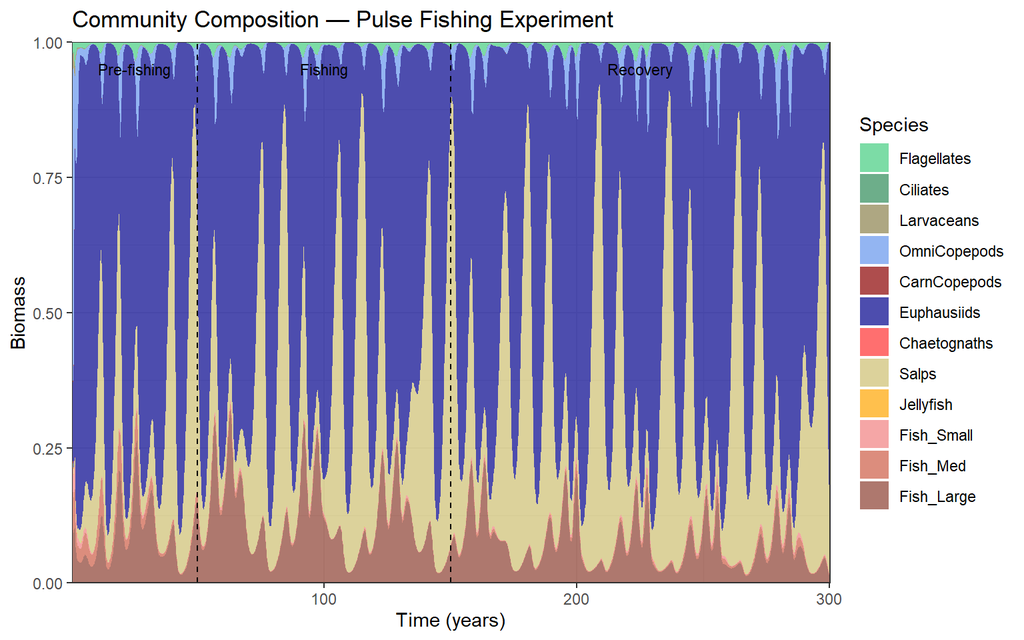

```r
p_fill_pulse <- plotTimeSeries(mdl_pulse, by = "biomass", type = "fill") +
  geom_vline(xintercept = c(50, 150), linetype = "dashed", colour = "black") +
  annotate("text", x = 25, y = 0.95, label = "Pre-fishing", size = 3) +
  annotate("text", x = 100, y = 0.95, label = "Fishing", size = 3) +
  annotate("text", x = 225, y = 0.95, label = "Recovery", size = 3) +
  ggtitle("Community Composition — Pulse Fishing Experiment")

p_fill_pulse
```

## Part 7: Ramping Effort (Historical Fishing Expansion)

A more realistic scenario: fishing effort increases gradually over time, mimicking the historical expansion of industrial fishing.

```r
time_ramp <- seq(0, 200, by = 0.1)
n_ramp <- length(time_ramp)

# No fishing for first 50 years (spin-up), then linear ramp from 0 to 3
effort_ramp <- pmax(0, (time_ramp - 50) / 50)  # reaches 1.0 at year 100, 3.0 at year 200

Groups_ramp <- setFishingParams(Groups,
                                q_small = 0.01,
                                q_med   = 0.02,
                                q_large = 0.03)
```

```
#> Fishing parameters set:
#>    Fish_Small : q = 0.01 , selectivity range [ 0 , 2 ] log10 g
#>    Fish_Med : q = 0.02 , selectivity range [ 2 , 4 ] log10 g
#>    Fish_Large : q = 0.03 , selectivity range [ 4 , 6 ] log10 g
```

```r
env_ramp <- createInputParams(time = time_ramp, sst = 15, chl = 1.0)
```

```
#> ZooMSS input parameters created:
#> - Time points: 2001 (time values provided)
#> - Time steps: 2000 (intervals to simulate)
#> - Time range: 0 to 200 years
#> - dt = 0.1 years
#> - SST range: 15 to 15 deg C
#> - Chlorophyll range: 1 to 1 mg/m^3
```

```r
env_ramp <- addFishingEffort(env_ramp,
                             effort_small = effort_ramp,
                             effort_med   = effort_ramp,
                             effort_large = effort_ramp)
```

```
#> Fishing effort added to input_params:
#>   effort_small: range [ 0 3 ]
#>   effort_med:   range [ 0 3 ]
#>   effort_large: range [ 0 3 ]
```

```r
mdl_ramp <- zoomss_model(input_params = env_ramp, Groups = Groups_ramp, isave = 5)
```

```
#> Calculating phytoplankton parameters from environmental time series
#> Energy budget loaded for 12 groups (Scenario A )
#>   f_M range:       0.3 0.55
#>   K_growth range:   0.25 0.55
#>   R_frac range:     0 0.2
#> Effort time series detected — enabling effort-driven fishing
#>   Catchability (q): Fish_Small = 0.01, Fish_Med = 0.02, Fish_Large = 0.03
#>   Effort columns: effort_small, effort_med, effort_large
```

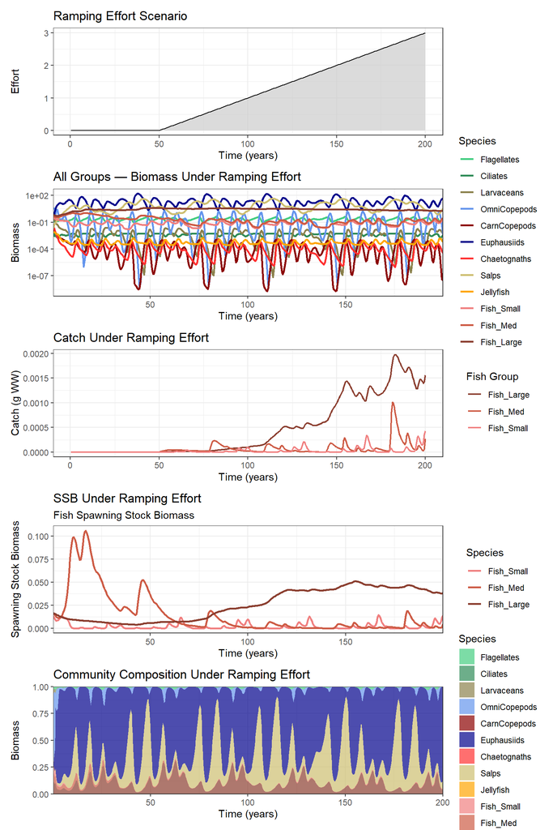

```r
# Effort ramp
effort_ramp_df <- data.frame(
  time = mdl_ramp$time,
  effort = approx(time_ramp, effort_ramp, xout = mdl_ramp$time)$y
)

p_eff_ramp <- ggplot(effort_ramp_df, aes(x = time, y = effort)) +
  geom_area(fill = "grey80", alpha = 0.7) +
  geom_line(linewidth = 0.5) +
  theme_bw() +
  labs(x = "Time (years)", y = "Effort", title = "Ramping Effort Scenario")

p_bm_ramp <- plotTimeSeries(mdl_ramp, by = "biomass", transform = "log10") +
  ggtitle("All Groups — Biomass Under Ramping Effort")

# Catch
catch_ramp <- extract_catch(mdl_ramp)
p_catch_ramp <- ggplot(catch_ramp, aes(x = time, y = catch, colour = group)) +
  geom_line(linewidth = 0.8) +
  scale_colour_manual(values = fish_colours) +
  theme_bw() +
  labs(x = "Time (years)", y = "Catch (g WW)",
       colour = "Fish Group", title = "Catch Under Ramping Effort")

p_ssb_ramp <- plotReproduction(mdl_ramp, by = "SSB") +
  ggtitle("SSB Under Ramping Effort")

p_fill_ramp <- plotTimeSeries(mdl_ramp, by = "biomass", type = "fill") +
  ggtitle("Community Composition Under Ramping Effort")

wrap_plots(p_eff_ramp, p_bm_ramp, p_catch_ramp, p_ssb_ramp, p_fill_ramp, ncol = 1)
```

As effort ramps up, watch for: - The point where catch for each group peaks and then declines (approaching or exceeding MSY) - Progressive depletion of fish groups from largest to smallest - Shifts in community composition toward zooplankton dominance

## Part 8: Catchability Sensitivity Analysis

To understand how catchability (q) influences equilibrium biomass and yield, we hold effort constant and vary q across a range of values for each size group. This helps identify thresholds where increased catchability leads to disproportionate biomass decline or yield collapse.

```r
q_levels <- c(0.001, 0.005, 0.01, 0.02, 0.05, 0.1, 0.2, 0.5, 1)

results_q <- list()

for (i in seq_along(q_levels)) {
  Groups_q <- setFishingParams(Groups,
                               q_small = q_levels[i],
                               q_med   = q_levels[i],
                               q_large = q_levels[i])

  env_q <- createInputParams(
    time = seq(0, 200, by = 0.1),
    sst = 15,
    chl = 1.0
  )

  env_q <- addFishingEffort(env_q,
                            effort_small = 1.0,
                            effort_med   = 1.0,
                            effort_large = 1.0)

  results_q[[i]] <- zoomss_model(
    input_params = env_q,
    Groups = Groups_q,
    isave = 5
  )
}
```

```
#> Fishing parameters set:
#>    Fish_Small : q = 0.001 , selectivity range [ 0 , 2 ] log10 g
#>    Fish_Med : q = 0.001 , selectivity range [ 2 , 4 ] log10 g
#>    Fish_Large : q = 0.001 , selectivity range [ 4 , 6 ] log10 g
#> ZooMSS input parameters created:
#> - Time points: 2001 (time values provided)
#> - Time steps: 2000 (intervals to simulate)
#> - Time range: 0 to 200 years
#> - dt = 0.1 years
#> - SST range: 15 to 15 deg C
#> - Chlorophyll range: 1 to 1 mg/m^3
#> Fishing effort added to input_params:
#>   effort_small: range [ 1 1 ]
#>   effort_med:   range [ 1 1 ]
#>   effort_large: range [ 1 1 ]
#> Calculating phytoplankton parameters from environmental time series
#> Energy budget loaded for 12 groups (Scenario A )
#>   f_M range:       0.3 0.55
#>   K_growth range:   0.25 0.55
#>   R_frac range:     0 0.2
#> Effort time series detected — enabling effort-driven fishing
#>   Catchability (q): Fish_Small = 0.001, Fish_Med = 0.001, Fish_Large = 0.001
#>   Effort columns: effort_small, effort_med, effort_large
#> Fishing parameters set:
#>    Fish_Small : q = 0.005 , selectivity range [ 0 , 2 ] log10 g
#>    Fish_Med : q = 0.005 , selectivity range [ 2 , 4 ] log10 g
#>    Fish_Large : q = 0.005 , selectivity range [ 4 , 6 ] log10 g
#> ZooMSS input parameters created:
#> - Time points: 2001 (time values provided)
#> - Time steps: 2000 (intervals to simulate)
#> - Time range: 0 to 200 years
#> - dt = 0.1 years
#> - SST range: 15 to 15 deg C
#> - Chlorophyll range: 1 to 1 mg/m^3
#> Fishing effort added to input_params:
#>   effort_small: range [ 1 1 ]
#>   effort_med:   range [ 1 1 ]
#>   effort_large: range [ 1 1 ]
#> Calculating phytoplankton parameters from environmental time series
#> Energy budget loaded for 12 groups (Scenario A )
```

[output cut: 152 more lines]

```
#> - dt = 0.1 years
#> - SST range: 15 to 15 deg C
#> - Chlorophyll range: 1 to 1 mg/m^3
#> Fishing effort added to input_params:
#>   effort_small: range [ 1 1 ]
#>   effort_med:   range [ 1 1 ]
#>   effort_large: range [ 1 1 ]
#> Calculating phytoplankton parameters from environmental time series
#> Energy budget loaded for 12 groups (Scenario A )
#>   f_M range:       0.3 0.55
#>   K_growth range:   0.25 0.55
#>   R_frac range:     0 0.2
#> Effort time series detected — enabling effort-driven fishing
#>   Catchability (q): Fish_Small = 1, Fish_Med = 1, Fish_Large = 1
#>   Effort columns: effort_small, effort_med, effort_large
```

### Equilibrium Yield, Biomass, SSB and Recruitment vs Catchability

We extract equilibrium values (averaged over the final 20% of the time series) for each catchability level — the same approach used for the effort gradient in Part 4, but now sweeping across $q$ while effort is fixed at 1.0. Since $F = q \times \text{Effort}$, this directly reveals the sensitivity of equilibrium outcomes to the catchability parameter estimated during calibration.

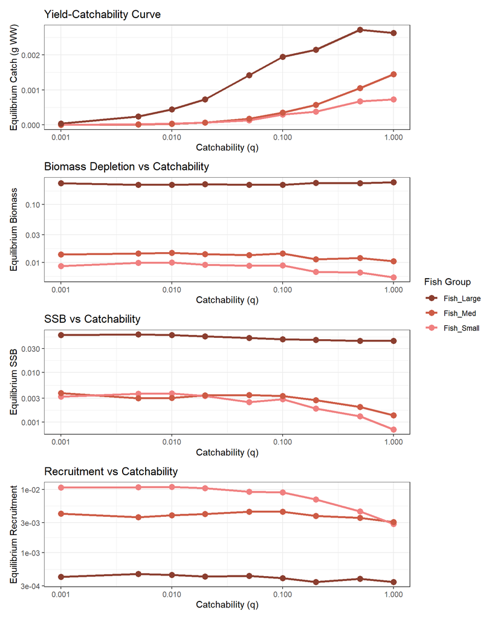

```r
num_fish <- 3
fish_names <- c("Fish_Small", "Fish_Med", "Fish_Large")

q_summary <- data.frame(
  q = rep(q_levels, each = num_fish),
  fish_group = rep(fish_names, length(q_levels)),
  eq_catch = NA,
  eq_biomass = NA,
  eq_SSB = NA,
  eq_recruitment = NA
)

for (i in seq_along(q_levels)) {
  mdl_i <- results_q[[i]]
  nsave <- length(mdl_i$time)
  fish_grps <- mdl_i$param$fish_grps

  # Average over final 20% of time series
  final_idx <- max(1, floor(nsave * 0.8)):nsave

  for (f in 1:num_fish) {
    row_idx <- (i - 1) * num_fish + f
    fg <- fish_grps[f]

    # Equilibrium biomass (from abundance)
    avg_biomass <- mean(apply(mdl_i$abundance[final_idx, fg, , drop = FALSE], 1, function(row) {
      sum(row * mdl_i$param$w * mdl_i$param$dx)
    }))
    q_summary$eq_biomass[row_idx] <- avg_biomass

    # Equilibrium SSB and recruitment
    q_summary$eq_SSB[row_idx] <- mean(mdl_i$SSB[final_idx, f], na.rm = TRUE)
    q_summary$eq_recruitment[row_idx] <- mean(mdl_i$recruitment[final_idx, f], na.rm = TRUE)

    # Equilibrium catch
    if (!is.null(mdl_i$catch)) {
      q_summary$eq_catch[row_idx] <- mean(mdl_i$catch[final_idx, f], na.rm = TRUE)
    } else {
      q_summary$eq_catch[row_idx] <- 0
    }
  }
}

fish_colours <- get_fish_colours(results_q[[1]])

# Yield-Catchability curve
p_yield_q <- ggplot(q_summary, aes(x = q, y = eq_catch, colour = fish_group)) +
  geom_line(linewidth = 1.2) +
  geom_point(size = 3) +
  scale_colour_manual(values = fish_colours) +
  scale_x_log10() +
  theme_bw() +
  labs(x = "Catchability (q)", y = "Equilibrium Catch (g WW)",
       title = "Yield-Catchability Curve", colour = "Fish Group")

# Biomass depletion vs q
p_biomass_q <- ggplot(q_summary, aes(x = q, y = eq_biomass, colour = fish_group)) +
  geom_line(linewidth = 1.2) +
  geom_point(size = 3) +
  scale_colour_manual(values = fish_colours) +
  scale_x_log10() +
  scale_y_log10() +
  theme_bw() +
  labs(x = "Catchability (q)", y = "Equilibrium Biomass",
       title = "Biomass Depletion vs Catchability", colour = "Fish Group")

# SSB vs q
p_ssb_q <- ggplot(q_summary, aes(x = q, y = eq_SSB, colour = fish_group)) +
  geom_line(linewidth = 1.2) +
  geom_point(size = 3) +
  scale_colour_manual(values = fish_colours) +
  scale_x_log10() +
  scale_y_log10() +
  theme_bw() +
  labs(x = "Catchability (q)", y = "Equilibrium SSB",
       title = "SSB vs Catchability", colour = "Fish Group")

# Recruitment vs q
p_rec_q <- ggplot(q_summary, aes(x = q, y = eq_recruitment, colour = fish_group)) +
  geom_line(linewidth = 1.2) +
  geom_point(size = 3) +
  scale_colour_manual(values = fish_colours) +
  scale_x_log10() +
  scale_y_log10() +
  theme_bw() +
  labs(x = "Catchability (q)", y = "Equilibrium Recruitment",
       title = "Recruitment vs Catchability", colour = "Fish Group")

wrap_plots(p_yield_q, p_biomass_q, p_ssb_q, p_rec_q, ncol = 1, guides = "collect")
```

The yield-catchability curve should show a similar dome shape to the yield-effort curve: at low $q$ values, increasing catchability increases catch proportionally; beyond some critical threshold, stock depletion dominates and total yield declines. Because $q$ acts as a multiplier on effort, the $q$ at peak yield approximates $q_{\text{MSY}}$ when effort is held at 1.0.

Note the log-scaled x-axis — catchability spans over two orders of magnitude, and the nonlinear response highlights how sensitive equilibrium outcomes are to this parameter. This underscores why accurate $q$ estimation during calibration is critical.

### Biomass Depletion Ratio

To express the impact of catchability in relative terms, we normalise equilibrium biomass against the unfished reference (lowest $q$ level, which has negligible fishing mortality).

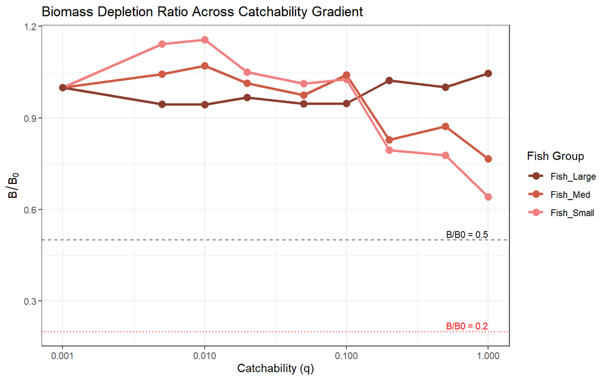

```r
# Calculate depletion ratio relative to lowest q (effectively unfished)
ref_biomass <- q_summary %>%
  filter(q == min(q_levels)) %>%
  select(fish_group, ref_biomass = eq_biomass)

q_depletion <- q_summary %>%
  left_join(ref_biomass, by = "fish_group") %>%
  mutate(depletion = eq_biomass / ref_biomass)

ggplot(q_depletion, aes(x = q, y = depletion, colour = fish_group)) +
  geom_line(linewidth = 1.2) +
  geom_point(size = 3) +
  geom_hline(yintercept = 0.5, linetype = "dashed", colour = "grey40") +
  geom_hline(yintercept = 0.2, linetype = "dotted", colour = "red") +
  annotate("text", x = max(q_levels), y = 0.52,
           label = "B/B0 = 0.5", hjust = 1, size = 3) +
  annotate("text", x = max(q_levels), y = 0.22,
           label = "B/B0 = 0.2", hjust = 1, size = 3, colour = "red") +
  scale_colour_manual(values = fish_colours) +
  scale_x_log10() +
  theme_bw() +
  labs(x = "Catchability (q)",
       y = expression(B / B[0]),
       title = "Biomass Depletion Ratio Across Catchability Gradient",
       colour = "Fish Group")
```

### Size Spectra: Low vs High Catchability

Comparing size spectra at the extremes of the catchability gradient reveals how gear efficiency reshapes community structure.

```r
idx_low <- 1                  # lowest q
idx_high <- length(q_levels)  # highest q

p_spec_low_q <- plotSizeSpectra(results_q[[idx_low]], n_years = 10) +
  ggtitle(paste0("Low Catchability (q = ", q_levels[idx_low], ") - Size Spectrum"))
```

```
#> Averaging final 10 years (20 saved time steps with isave = 5) of abundance from 400 total saved time steps.
```

```r
p_spec_high_q <- plotSizeSpectra(results_q[[idx_high]], n_years = 10) +
  ggtitle(paste0("High Catchability (q = ", q_levels[idx_high], ") - Size Spectrum"))
```

```
#> Averaging final 10 years (20 saved time steps with isave = 5) of abundance from 400 total saved time steps.
```

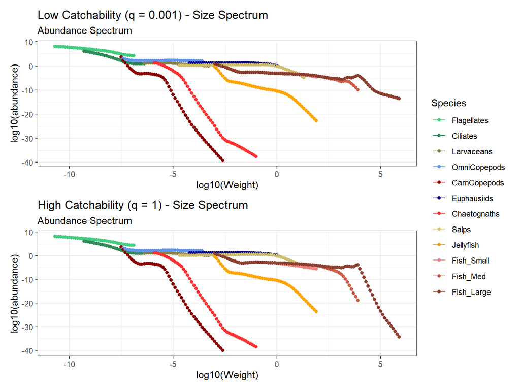

```r
wrap_plots(p_spec_low_q, p_spec_high_q, ncol = 1, guides = "collect")
```

## Summary

### Connection to FishMIP Calibration

The effort-driven framework demonstrated here is designed for calibration against observed catch data within the FishMIP (Fisheries and Marine Ecosystem Model Intercomparison Project) framework. The calibration process estimates catchability ($q$) and selectivity ($w_{min}$) by minimising the difference between predicted and observed catch:

$$\text{SSE} = \sum_t \left(
\text{Catch}_{\text{predicted}}(t) - \text{Catch}_{\text{observed}}(t)
\right)^2$$

See the calibration vignette (forthcoming) for details on parameter estimation using `calibrateFishing()`.